# 8: STAT 213 Review

Author

Bryana A. S. Thieret

## 8.1: STAT 213 with `broom`

- In the examples below, we will consider the multiple regression model

$$Y = \beta_0 + \beta_1species + \beta_2aroma + \beta_3 flavor + \beta_4sweetness + \beta_5moisture + \epsilon$$

- where $Y$ is the rating of the coffee (total_cup_points), species in an indicator variable equal to 1 if the species is Robusta and a 0 if the species is Arabica.

### 8.1.1: `tidy()`

- `tidy()` is analogous to `summary()` for a linear model.

```r
library(tidyverse)
library(broom)
library(here)
theme_set(theme_classic())

coffee_df <- read_csv(here("Section Notes/data/coffee_ratings.csv"))


coffee_mod <- lm(total_cup_points ~ species + aroma + flavor +
                   sweetness + moisture,
   data = coffee_df)
```

```r
summary(coffee_mod)
```

```
Call:
lm(formula = total_cup_points ~ species + aroma + flavor + sweetness +
    moisture, data = coffee_df)

Residuals:
    Min      1Q  Median      3Q     Max
-9.5132 -0.3705  0.0726  0.5610  5.5844

Coefficients:
               Estimate Std. Error t value Pr(>|t|)
(Intercept)     7.04039    0.77377   9.099  < 2e-16 ***
speciesRobusta  2.85365    0.26861  10.624  < 2e-16 ***
aroma           1.95188    0.14575  13.392  < 2e-16 ***
flavor          5.09440    0.14042  36.281  < 2e-16 ***
sweetness       2.23956    0.06553  34.173  < 2e-16 ***
moisture       -1.88033    0.67368  -2.791  0.00533 **
---
Signif. codes:  0 '***' 0.001 '**' 0.01 '*' 0.05 '.' 0.1 ' ' 1

Residual standard error: 1.168 on 1333 degrees of freedom
Multiple R-squared:  0.8891,    Adjusted R-squared:  0.8887
F-statistic:  2137 on 5 and 1333 DF,  p-value: < 2.2e-16
```

```r
tidy(coffee_mod)
```

```
# A tibble: 6 × 5
  term           estimate std.error statistic   p.value
  <chr>             <dbl>     <dbl>     <dbl>     <dbl>
1 (Intercept)        7.04    0.774       9.10 3.23e- 19
2 speciesRobusta     2.85    0.269      10.6  2.31e- 25
3 aroma              1.95    0.146      13.4  1.82e- 38
4 flavor             5.09    0.140      36.3  4.73e-201
5 sweetness          2.24    0.0655     34.2  2.41e-184
6 moisture          -1.88    0.674      -2.79 5.33e-  3
```

- The advantage of this format of output is that we can now use other `tidyverse` functions on the output.

```r
# to pull p-values
tidy(coffee_mod) |> select(p.value)
```

```
# A tibble: 6 × 1
    p.value
      <dbl>
1 3.23e- 19
2 2.31e- 25
3 1.82e- 38
4 4.73e-201
5 2.41e-184
6 5.33e-  3
```

```r
# grab the output for a particular variable of interest
tidy(coffee_mod) |> filter(term == "aroma")
```

```
# A tibble: 1 × 5
  term  estimate std.error statistic  p.value
  <chr>    <dbl>     <dbl>     <dbl>    <dbl>
1 aroma     1.95     0.146      13.4 1.82e-38
```

### 8.1.2: `glance()`

- `glance()` puts some model summary statistics into a tidy tibble.

```r
glance(coffee_mod)
```

```
# A tibble: 1 × 12
  r.squared adj.r.squared sigma statistic p.value    df logLik   AIC   BIC
      <dbl>         <dbl> <dbl>     <dbl>   <dbl> <dbl>  <dbl> <dbl> <dbl>
1     0.889         0.889  1.17     2137.       0     5 -2105. 4224. 4260.
# ℹ 3 more variables: deviance <dbl>, df.residual <int>, nobs <int>
```

### 8.1.3: `augment()`

- `augment()` returns a tibble that contains all of the variables used to fit the model appended with commonly used diagnostic statistics like the fitted values, cooks distance, values for leverage, and residuals.

```r
augment(coffee_mod)
```

```
# A tibble: 1,339 × 12
   total_cup_points species aroma flavor sweetness moisture .fitted  .resid
              <dbl> <chr>   <dbl>  <dbl>     <dbl>    <dbl>   <dbl>   <dbl>
 1             90.6 Arabica  8.67   8.83     10        0.12    91.1 -0.537
 2             89.9 Arabica  8.75   8.67     10        0.12    90.5 -0.538
 3             89.8 Arabica  8.42   8.5      10        0       89.2  0.577
 4             89   Arabica  8.17   8.58     10        0.11    88.9  0.114
 5             88.8 Arabica  8.25   8.5      10        0.12    88.6  0.214
 6             88.8 Arabica  8.58   8.42     10        0.11    88.9 -0.0411
 7             88.8 Arabica  8.42   8.5      10        0.11    89.0 -0.216
 8             88.7 Arabica  8.25   8.33      9.33     0.03    86.4  2.25
 9             88.4 Arabica  8.67   8.67      9.33     0.03    89.0 -0.550
10             88.2 Arabica  8.08   8.58     10        0.1     88.7 -0.479
# ℹ 1,329 more rows
# ℹ 4 more variables: .hat <dbl>, .sigma <dbl>, .cooksd <dbl>, .std.resid <dbl>
```

```r
# filter() the data set to examine values with high cook's distance that might be influential

augment_df = augment(coffee_mod)
augment_df |> filter(.cooksd > 1)
```

```
# A tibble: 1 × 12
  total_cup_points species aroma flavor sweetness moisture .fitted .resid  .hat
             <dbl> <chr>   <dbl>  <dbl>     <dbl>    <dbl>   <dbl>  <dbl> <dbl>
1                0 Arabica     0      0         0     0.12    6.81  -6.81 0.430
# ℹ 3 more variables: .sigma <dbl>, .cooksd <dbl>, .std.resid <dbl>
```

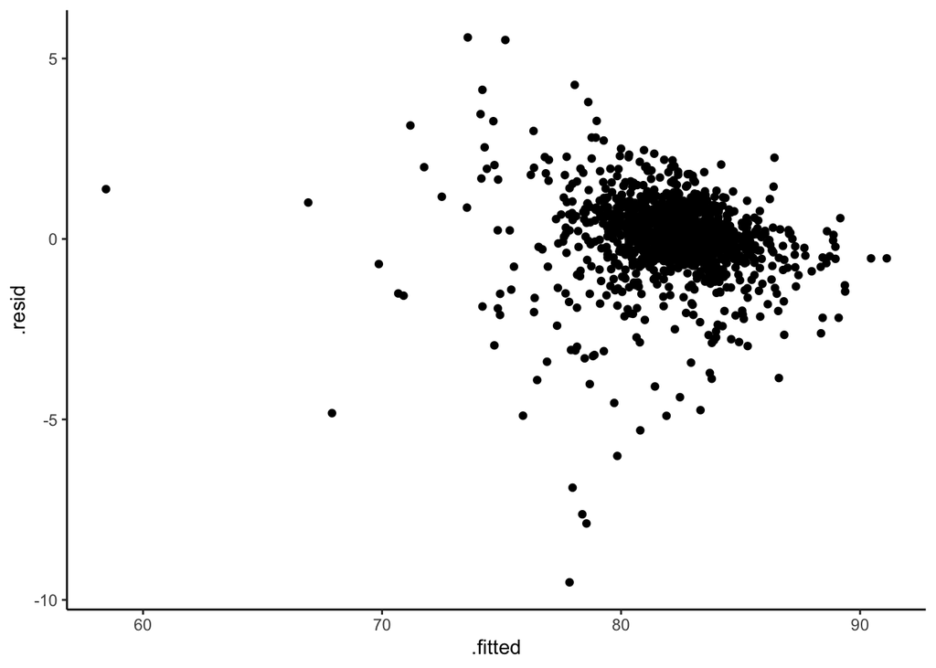

```r
augment_df |> filter(.fitted > 25) |>
  ggplot(aes(x = .fitted, y = .resid)) +
  geom_point()
```

### 8.1.4: Exercises

**Exercise 1:** Examine the penguins data set in the palmerpenguins package. Fit a linear regression model with body_mass_g as the response variable and species and bill_length_mm as the predictors. Note that penguins with missing values for any of these three variables will be dropped from the analysis.

```r
library(palmerpenguins)
penguins
```

```
# A tibble: 344 × 8
   species island    bill_length_mm bill_depth_mm flipper_length_mm body_mass_g
   <fct>   <fct>              <dbl>         <dbl>             <int>       <int>
 1 Adelie  Torgersen           39.1          18.7               181        3750
 2 Adelie  Torgersen           39.5          17.4               186        3800
 3 Adelie  Torgersen           40.3          18                 195        3250
 4 Adelie  Torgersen           NA            NA                  NA          NA
 5 Adelie  Torgersen           36.7          19.3               193        3450
 6 Adelie  Torgersen           39.3          20.6               190        3650
 7 Adelie  Torgersen           38.9          17.8               181        3625
 8 Adelie  Torgersen           39.2          19.6               195        4675
 9 Adelie  Torgersen           34.1          18.1               193        3475
10 Adelie  Torgersen           42            20.2               190        4250
# ℹ 334 more rows
# ℹ 2 more variables: sex <fct>, year <int>
```

```r
pen_mod1 = lm(body_mass_g ~ bill_length_mm, data = penguins)
```

**Exercise 2:** Create a table of summary output, including coefficient estimates, standard errors, test statistics, and p-values, using one of the broom functions.

```r
tidy(pen_mod1)
```

```
# A tibble: 2 × 5
  term           estimate std.error statistic  p.value
  <chr>             <dbl>     <dbl>     <dbl>    <dbl>
1 (Intercept)       362.     283.        1.28 2.02e- 1
2 bill_length_mm     87.4      6.40     13.7  3.81e-34
```

**Exercise 3:** Use glance() to glance at some of the relevant model statistics.

```r
glance(pen_mod1)
```

```
# A tibble: 1 × 12
  r.squared adj.r.squared sigma statistic  p.value    df logLik   AIC   BIC
      <dbl>         <dbl> <dbl>     <dbl>    <dbl> <dbl>  <dbl> <dbl> <dbl>
1     0.354         0.352  645.      186. 3.81e-34     1 -2697. 5400. 5411.
# ℹ 3 more variables: deviance <dbl>, df.residual <int>, nobs <int>
```

**Exercise 4:** Using augment(), create a plot of the residuals vs. the fitted values and evaluate the constant variance assumption.

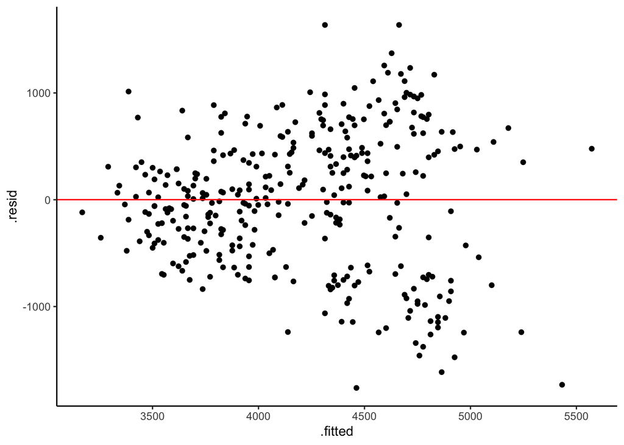

```r
augment(pen_mod1) |> ggplot(aes(x = .fitted, y = .resid)) +
  geom_point() +
  geom_hline(yintercept = 0.5, color = "red")
```

**Exercise 5:** Using augment(), check to see if there are any penguins that are influential. Use 0.75 as your cut-off value for Cook’s distance.

```r
augment(pen_mod1) |> filter(.cooksd > .75)
```

```
# A tibble: 0 × 9
# ℹ 9 variables: .rownames <chr>, body_mass_g <int>, bill_length_mm <dbl>,
#   .fitted <dbl>, .resid <dbl>, .hat <dbl>, .sigma <dbl>, .cooksd <dbl>,
#   .std.resid <dbl>
```

- There are no penguins that are particularly influential in this data set.

*—————————————————————————————–*

## 8.2: Model Coefficient Interpretation